# Pg. Web grupal

Author

Noelia, Alexandra, Diomer, Luis, Nixon, Carmen

**Grupo 6: Trabajo final de Unidad II**

**Integrantes del grupo:**

Bustamante López Noelia Patricia

Cubas Vasquez Luis Alberto

Goicochea Gonzáles Alexandra Lucía

Mendoza Huaman Diomer

Palacios Tejedo Nixon

Tarrillo Trujillano Carmen Rosa

# 1 Procedimiento

1. En GitHub, se creo un nuevo repositorio llamado `` ` ```Pg.-Web-grupal``` `. ``
2. En R se creo un nuevo proyecto denominado `T.Unidad 2º Pg Web`.
3. Vincular repositorio con el nuevo proyecto, ingresando los siguientes comandos en la terminal:

   git init git add README.md git commit -m “primer commit” git branch -M main git remote add origin https://github.com/Luis-cubas-cmd/Pg.-Web-grupalgit push -u origin main
4. Para actualizar el contenido de la pagina web, se ejecuntan los siguientes comandos en la terminal:

   git add . git commit -m “primer commit” git push

# 2 Importación de base de datos

```r
source('https://inkaverse.com/setup.r')
```

```
ℹ The googlesheets4 package is using a cached token for
  'luisalbertocubasvasquez32@gmail.com'.
```

```
ℹ The googledrive package is using a cached token for
  'luisalbertocubasvasquez32@gmail.com'.
```

```r
library(readxl)
data <- read_excel("LA MOLINA 2014 POTATO WUE (FB).xlsx", sheet = "fb")
```

## 2.1 Elección de variables

De la base de datos se han elegido las siguientes variables:

Leaf Dry Weight (leafdw)

Total Transpiration (ttrans)

# 3 Modelo lineales

## 3.1 Modelo lineal para la variable Leaf Dry Weight (leafdw)

A continuación, se realizará un análisis de varianza (ANOVA) utilizando el siguiente código en R:

```r
modelo1 <- aov(formula = leafdw ~ bloque + riego + geno + riego*geno, data= data)

anova(modelo1)
## Analysis of Variance Table
##
## Response: leafdw
##             Df  Sum Sq Mean Sq  F value               Pr(>F)
## bloque       4   26.13    6.53   1.1810              0.32286
## riego        1 1065.87 1065.87 192.6695 < 0.0000000000000002 ***
## geno        14 2437.24  174.09  31.4688 < 0.0000000000000002 ***
## riego:geno  14  172.96   12.35   2.2332              0.01023 *
## Residuals  116  641.72    5.53
## ---
## Signif. codes:  0 '***' 0.001 '**' 0.01 '*' 0.05 '.' 0.1 ' ' 1
```

Este análisis de varianza (ANOVA) evalúa los efectos de tres factores —el bloque, el nivel de riego y el genotipo (geno)— en el peso seco de las hojas (“Leaf Dry Weight” o leafdw), además de considerar la interacción entre riego y genotipo.

### 3.1.1 Interpretacion de resultados

#### 3.1.1.1 BLOQUE

No tuvo un efecto significativo en leafdw(F = 1.1810, p = 0.32286), lo que sugiere que las variaciones debidas a bloques son mínimas en comparación con los otros factores.

#### 3.1.1.2 RIEGO

Tiene un efecto altamente significativo en el peso seco de las hojas (F = 192.6695, p < 0.0000000000000002), indicando que el nivel de riego influye fuertemente en leafdw.

#### 3.1.1.3 GENOTIPO

También muestra un efecto altamente significativo en leafdw(F = 31.4688, p < 0.00000000000000002), lo que sugiere que diferentes genotipos afectan de manera significativa el peso seco de las hojas.

#### 3.1.1.4 INTERACCION RIEGO-GENOTIPO

Presenta un efecto significativo (F = 2.2332, p = 0.01023), lo que implica que el impacto del riego en el peso seco de las hojas varía según el genotipo.

**En conjunto, el análisis sugiere que tanto el riego como el genotipo, además de su interacción, tienen efectos importantes en el peso seco de las hojas.**

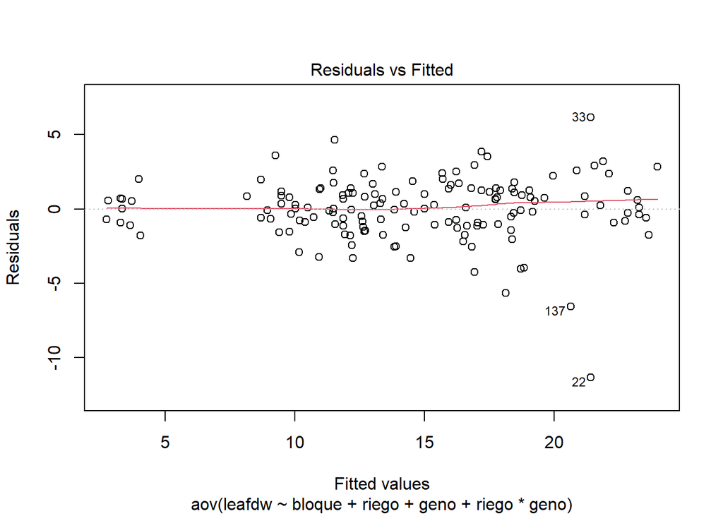

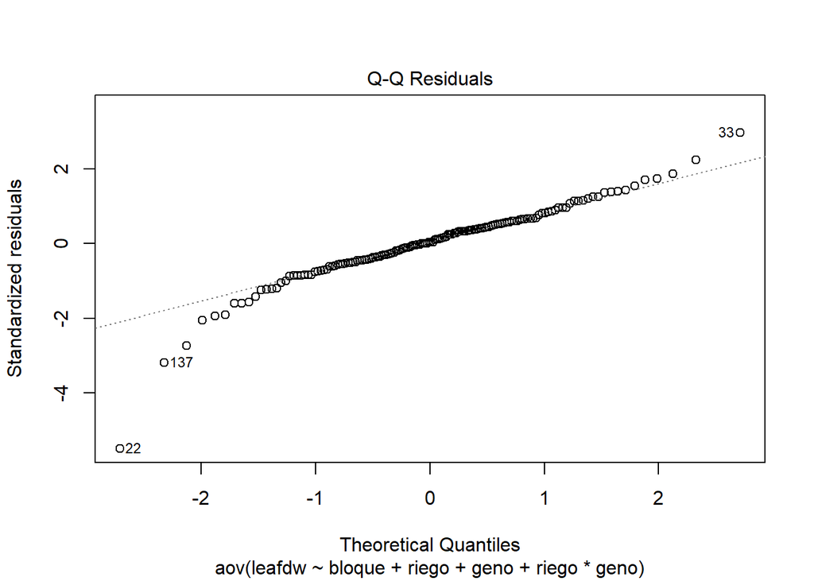

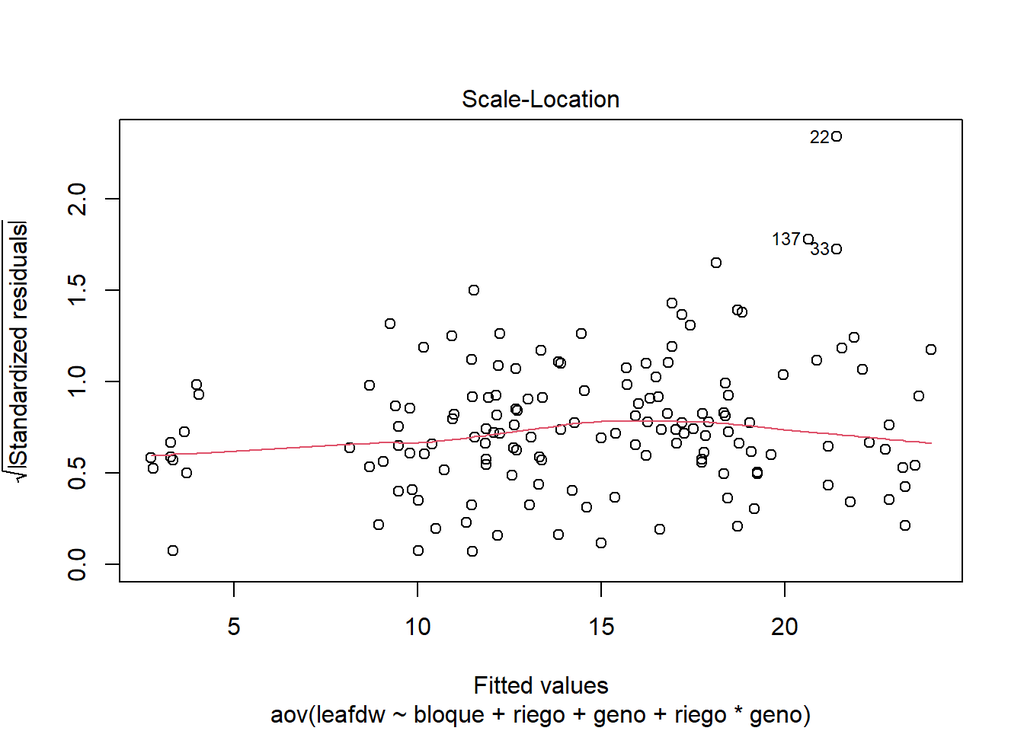

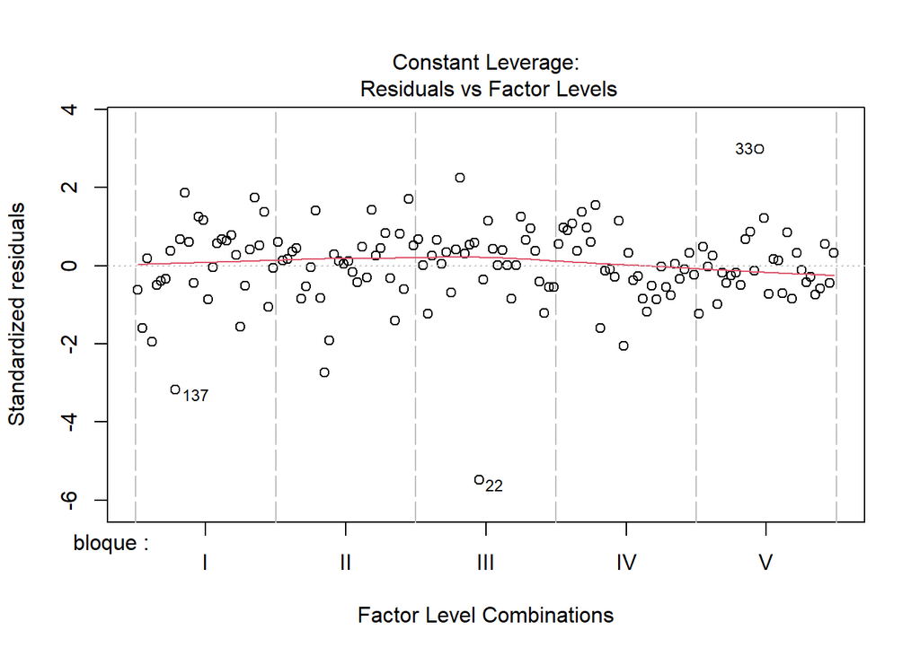

```r
plot(modelo1)
```

## 3.2 Bloxplot

El siguiente comando en R utiliza ggplot2 para crear un gráfico de caja (“boxplot”) que muestra la distribución del peso seco de las hojas (leafdw) en función de cada genotipo (geno), diferenciando los niveles de riego (riego) mediante colores.

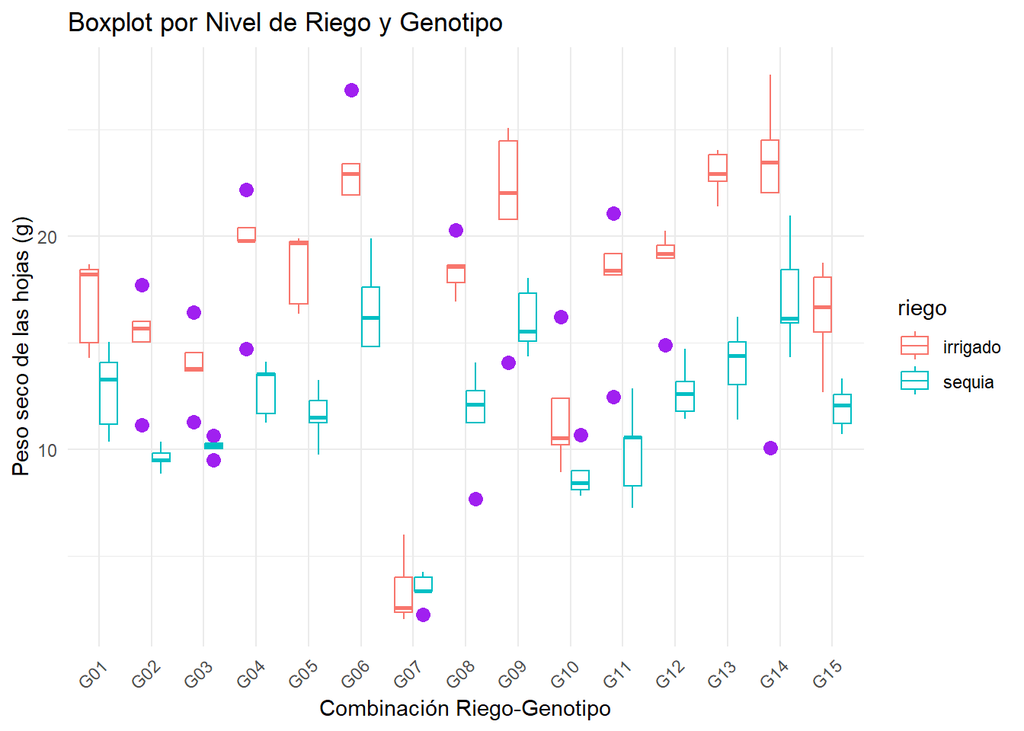

```r
library(ggplot2)
ggplot(data, aes(x = geno, y = leafdw, colour = riego)) +
  geom_boxplot(outlier.colour = "purple", outlier.shape = 16, outlier.size = 3) +
  labs(title = "Boxplot por Nivel de Riego y Genotipo", x = "Combinación Riego-Genotipo", y = "Peso seco de las hojas (g)") +
  theme_minimal() +
  theme(axis.text.x = element_text(angle = 45, hjust = 1))
```

### 3.2.1 Descripcion de la grafica

**Eje X:** Representa los distintos genotipos (geno), con cada combinación de riego y genotipo agrupada en el eje horizontal.

**Eje Y**: Indica el peso seco de las hojas (leafdw) en gramos.

**Colores:** Diferencian los niveles de riego (riego), permitiendo una comparación visual entre los efectos del riego dentro de cada genotipo.

**Puntos atípicos:** Los valores atípicos se muestran como puntos de color púrpura, con una forma circular y tamaño de 3, destacándose en cada grupo.

**Título y Etiquetas:** El gráfico tiene un título claro, “Boxplot por Nivel de Riego y Genotipo,” junto con etiquetas descriptivas para los ejes, especificando “Peso seco de las hojas (g)” en el eje Y y “Combinación Riego-Genotipo” en el eje X.

**Estilo y Rotación de Texto:** Se aplica un tema minimalista (theme_minimal()) para mejorar la claridad visual del gráfico, y el texto del eje X se rota 45 grados para facilitar la lectura de las etiquetas.

**Este gráfico permite visualizar de manera eficiente la variabilidad del peso seco de las hojas entre genotipos y cómo los diferentes niveles de riego influyen en esta variación.**

## 3.3 Modelo lineal para la variable transpiracion total (ttrans)

A continuación, se realizará un análisis de varianza (ANOVA) utilizando el siguiente código en R:

```r
modelo2 <- aov(formula = ttrans ~ bloque + riego + geno + riego*geno, data= data)
anova(modelo2)
## Analysis of Variance Table
##
## Response: ttrans
##             Df Sum Sq Mean Sq  F value               Pr(>F)
## bloque       4  17.49    4.37   3.4162              0.01114 *
## riego        1 416.31  416.31 325.3217 < 0.0000000000000002 ***
## geno        14 272.13   19.44  15.1897 < 0.0000000000000002 ***
## riego:geno  14  29.71    2.12   1.6585              0.07398 .
## Residuals  116 148.44    1.28
## ---
## Signif. codes:  0 '***' 0.001 '**' 0.01 '*' 0.05 '.' 0.1 ' ' 1
```

### 3.3.1 Interpretacion de resultados

#### 3.3.1.1 BLOQUE

Tiene un efecto significativo en la transpiración total (ttrans) (F = 3.4162, p = 0.01114), lo cual sugiere que hay una variación en la transpiración entre bloques.

#### 3.3.1.2 RIEGO

Muestra un efecto altamente significativo en la transpiración (F = 325.3217, p < 0.0000000000000002), lo que indica que el nivel de riego tiene un impacto considerable sobre la transpiración total.

#### 3.3.1.3 GENO

También tiene un efecto altamente significativo en ttrans (F = 15.1897, p < 0.0000000000000002), lo cual sugiere que el genotipo influye fuertemente en la cantidad de transpiración.

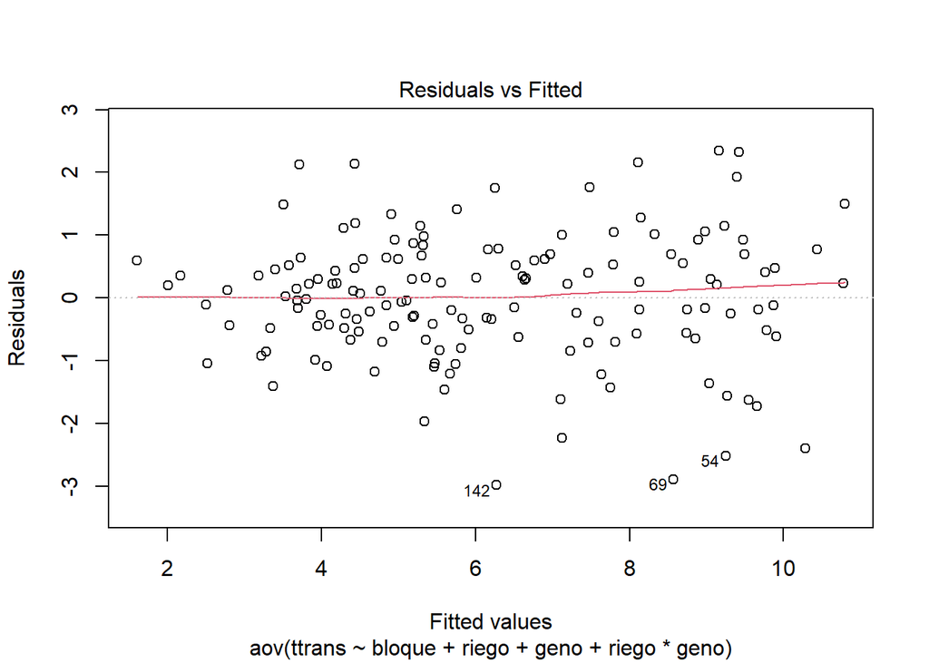

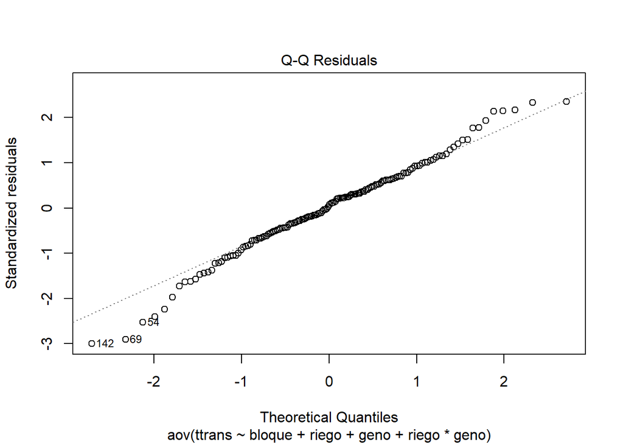

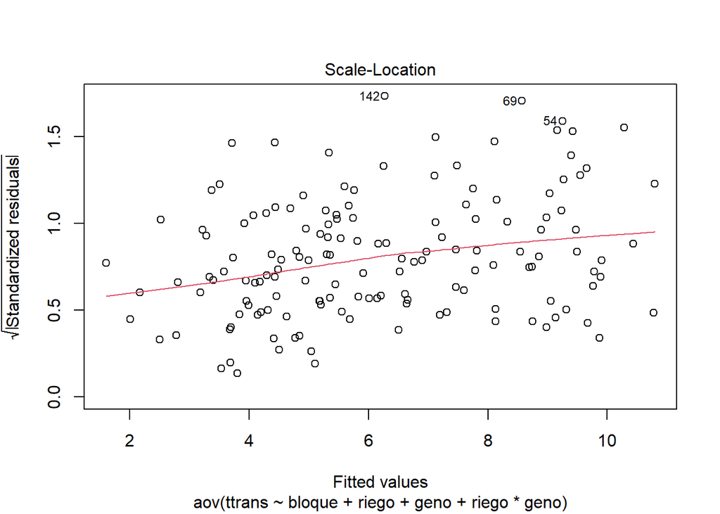

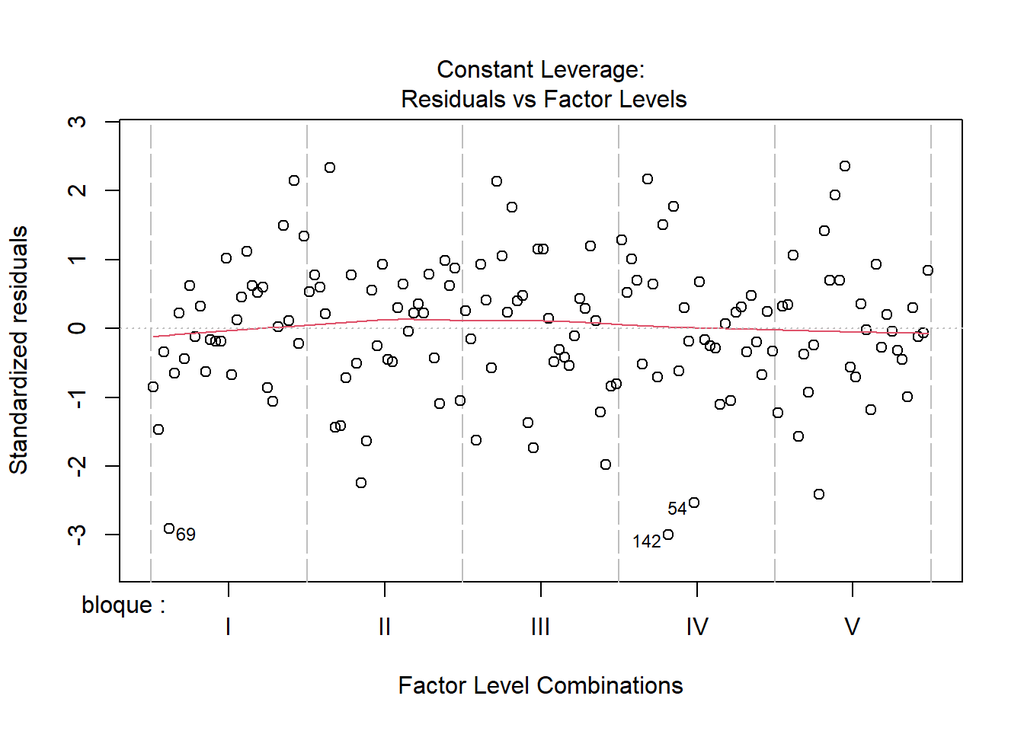

```r
plot(modelo2)
```

### 3.3.2 Bloxplot

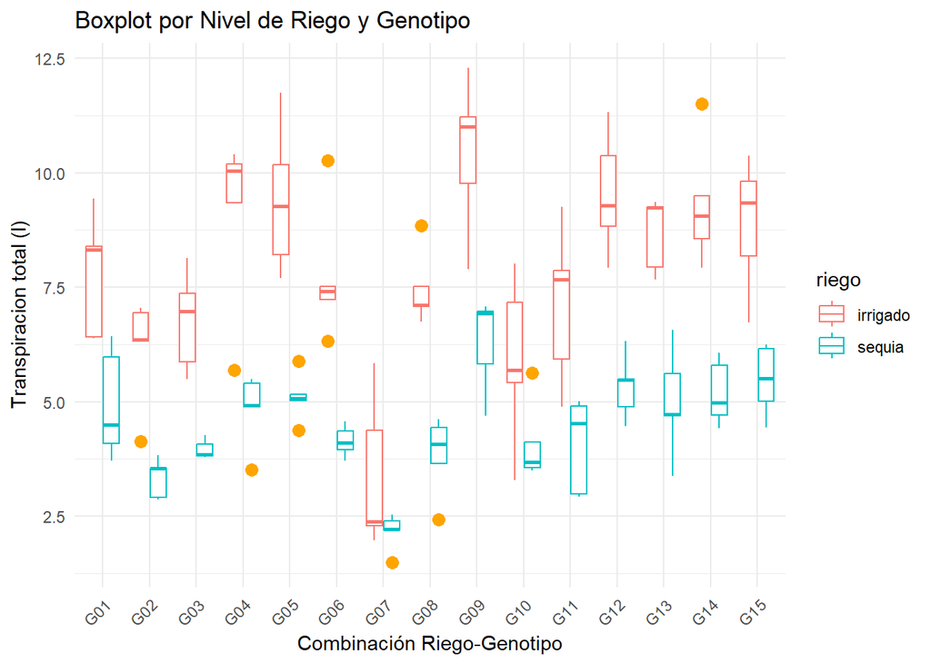

```r
library(ggplot2)
ggplot(data, aes(x = geno, y = ttrans, colour = riego)) +
  geom_boxplot(outlier.colour = "orange", outlier.shape = 16, outlier.size = 3) +
  labs(title = "Boxplot por Nivel de Riego y Genotipo", x = "Combinación Riego-Genotipo", y = "Transpiracion total (l)") +
  theme_minimal() +
  theme(axis.text.x = element_text(angle = 45, hjust = 1))
```

# 4 Modelos lineales mixtos

## 4.1 Modelo lineal mixto para la variable Leaf Dry Weight (leafdw)

```r
library(lme4)

modelo1_mixto <- lmer(leafdw ~ riego * geno + (1 | bloque), data = data)

anova(modelo1_mixto)
## Analysis of Variance Table
##            npar  Sum Sq Mean Sq  F value
## riego         1 1065.87 1065.87 192.6695
## geno         14 2437.24  174.09  31.4688
## riego:geno   14  172.96   12.35   2.2332
```

### 4.1.1 Interpretacion de resultados

**riego:** Tiene un efecto altamente significativo (F = 192.6695), lo que indica que el nivel de riego influye de manera considerable en la variable de respuesta. La suma de cuadrados (Sum Sq = 1065.87) muestra que este factor explica una gran parte de la variación en los datos.

**geno:** También muestra un efecto significativo (F = 31.4688), lo que sugiere que diferentes genotipos afectan significativamente la variable de respuesta. Su suma de cuadrados (Sum Sq = 2437.24) indica que el genotipo es un factor importante en la variabilidad observada.

**interacción entre riego y genotipo:** La interacción entre riego y genotipo tiene un efecto significativo (F = 2.2332), aunque menos fuerte que los efectos principales de riego y genotipo. Esto sugiere que el efecto del riego sobre la variable de respuesta varía en función del genotipo, lo cual podría indicar que ciertos genotipos responden de manera diferente a los niveles de riego

**El modelo sugiere que tanto el riego como el genotipo tienen efectos importantes en la variable de respuesta, con una interacción significativa que indica que la respuesta al riego depende del genotipo específico.**

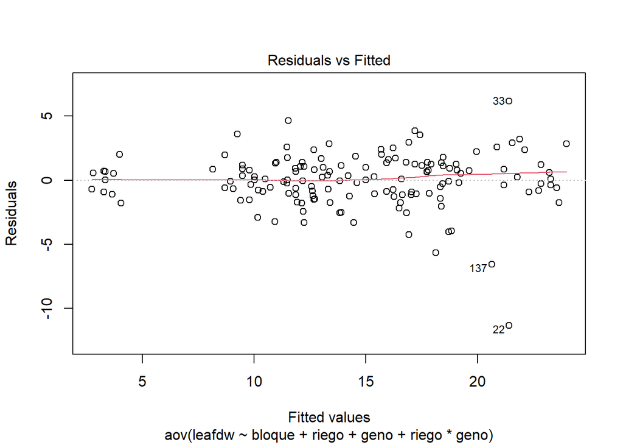

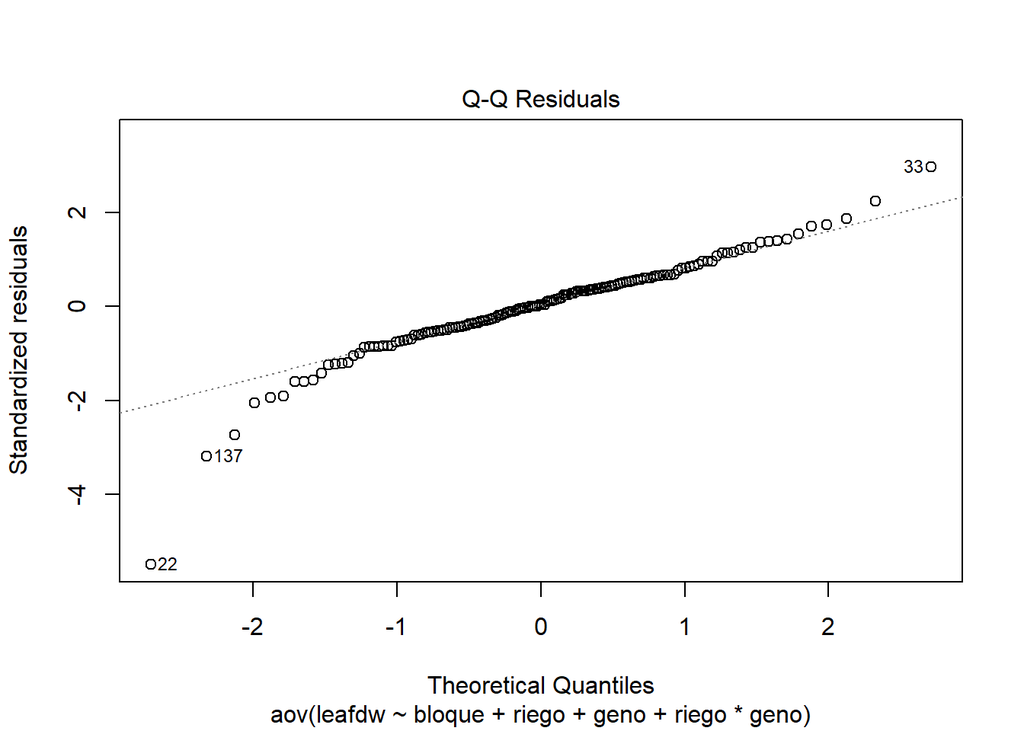

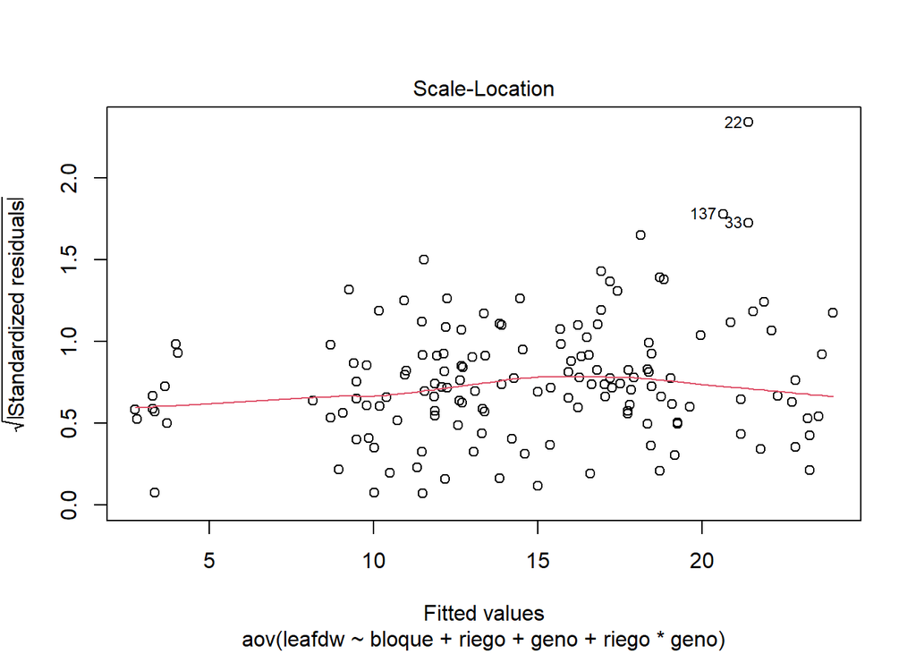

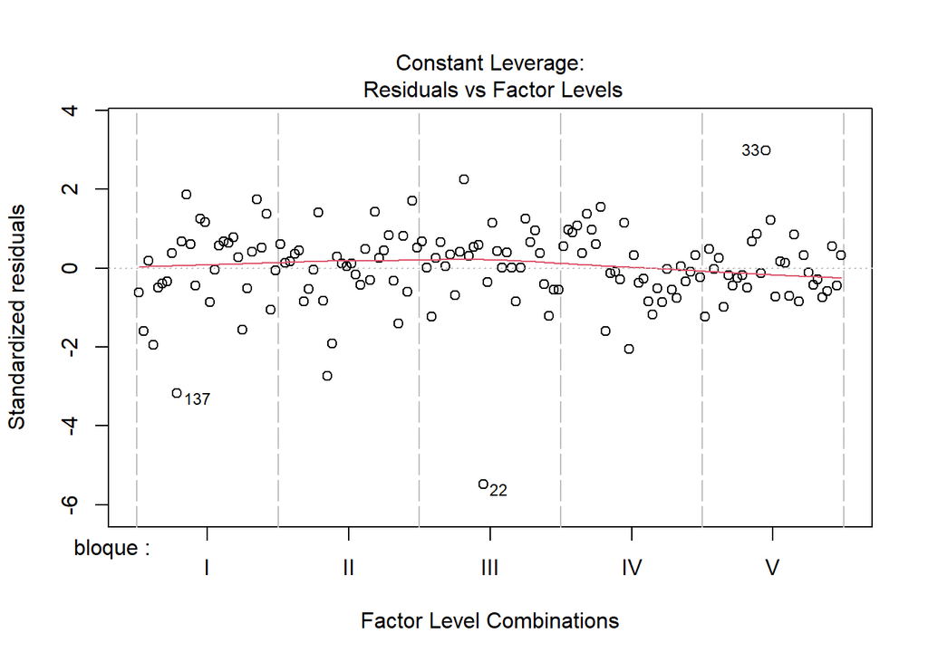

```r
plot(modelo1)
```